# Predicting Candidate Attendance in Interviews

## ABOUT DATASET

The dataset comprises details of over 1000 candidates and their interview experiences throughout the period from 2014 to 2016

#### **Attribute Information**:

1. Date of Interview:
   - The scheduled day for the candidate's interview. Formats may vary.
2. Client Name:
   - The client who provided the recruitment mandate to the vendor.
3. Industry:
   - The vertical or industry to which the client belongs. Candidates may explore different industries during their job search.
4. Location:
   - The current location of the candidate.
5. Position to be Closed:
   - "Niche" refers to rare skill sets, while "routine" refers to more common skill sets.
6. Nature of Skillset:
   - The specific skill set that the client is looking for.
7. Interview Type:
   - Three types of interviews - Walkin drives, Scheduled interviews, and Scheduled Walkins. Each has unique characteristics.
8. Name (Cand ID):
   - A substitute to keep the candidate's identity confidential.
9. Gender:
   - Indicates whether the candidate is male or female.
10. Candidate Current Location:
    - The current location of the candidate.
11. Candidate Job Location:
    - The expected job location for the candidate.
12. Interview Venue:
    - The location where the interview is conducted.
13. Candidate Native Location:
    - The candidate's place of origin.
14. Permission to Start:
    - Whether the candidate has obtained the necessary permission to start at the required time.
15. No Unscheduled Meetings:
    - Whether the candidate anticipates any unscheduled meetings.
16. Three-Hour Call Permission:
    - Can the interviewer call the candidate three hours before the interview for attendance follow-up.
17. Alternative Number/Desk Number:
    - Can the interviewer contact the candidate using an alternative number or desk number.
18. Updated Resume and JD Understanding:
    - Whether the candidate has a printout of the updated resume and has read and understood the job description (JD).
19. Venue Details and Landmark Clarity:
    - Whether the candidate is clear about the interview venue details and landmarks.
20. Call Letter Sharing:
    - Whether the call letter for the interview has been shared with the candidate.
21. Expected Attendance:
    - Whether the candidate was expected to attend the interview (Yes, No, or Uncertain).
22. Observed Attendance:
    - Binary variable indicating whether the candidate attended the interview. This is the dependent variable.
23. Marital Status:
    - Indicates whether the candidate is married or single.

## Import Libraries

```python
import numpy as np
import pandas as pd
import seaborn as sns
import matplotlib.pyplot as plt
%matplotlib inline
from sklearn.metrics import confusion_matrix, accuracy_score
import pandas_profiling as pp
```

```python
# !pip install --upgrade phik
# !pip install --upgrade numba
```

## Load dataset

```python
df = pd.read_csv('/kaggle/input/the-interview-attendance-problem/Interview.csv')
```

## Explore Dataset

```python
df.info()
```

```
<class 'pandas.core.frame.DataFrame'>
RangeIndex: 1234 entries, 0 to 1233
Data columns (total 28 columns):
 #   Column                                                                                              Non-Null Count  Dtype
---  ------                                                                                              --------------  -----
 0   Date of Interview                                                                                   1233 non-null   object
 1   Client name                                                                                         1234 non-null   object
 2   Industry                                                                                            1233 non-null   object
 3   Location                                                                                            1233 non-null   object
 4   Position to be closed                                                                               1233 non-null   object
 5   Nature of Skillset                                                                                  1233 non-null   object
 6   Interview Type                                                                                      1233 non-null   object
 7   Name(Cand ID)                                                                                       1233 non-null   object
 8   Gender                                                                                              1233 non-null   object
 9   Candidate Current Location                                                                          1233 non-null   object
```

[output cut: 20 more lines]

```python
df.head(5)
```

|  | Date of Interview | Client name | Industry | Location | Position to be closed | Nature of Skillset | Interview Type | Name(Cand ID) | Gender | Candidate Current Location | ... | Are you clear with the venue details and the landmark. | Has the call letter been shared | Expected Attendance | Observed Attendance | Marital Status | Unnamed: 23 | Unnamed: 24 | Unnamed: 25 | Unnamed: 26 | Unnamed: 27 |
| --- | --- | --- | --- | --- | --- | --- | --- | --- | --- | --- | --- | --- | --- | --- | --- | --- | --- | --- | --- | --- | --- |
| 0 | 13.02.2015 | Hospira | Pharmaceuticals | Chennai | Production- Sterile | Routine | Scheduled Walkin | Candidate 1 | Male | Chennai | ... | Yes | Yes | Yes | No | Single | NaN | NaN | NaN | NaN | NaN |
| 1 | 13.02.2015 | Hospira | Pharmaceuticals | Chennai | Production- Sterile | Routine | Scheduled Walkin | Candidate 2 | Male | Chennai | ... | Yes | Yes | Yes | No | Single | NaN | NaN | NaN | NaN | NaN |
| 2 | 13.02.2015 | Hospira | Pharmaceuticals | Chennai | Production- Sterile | Routine | Scheduled Walkin | Candidate 3 | Male | Chennai | ... | NaN | NaN | Uncertain | No | Single | NaN | NaN | NaN | NaN | NaN |
| 3 | 13.02.2015 | Hospira | Pharmaceuticals | Chennai | Production- Sterile | Routine | Scheduled Walkin | Candidate 4 | Male | Chennai | ... | Yes | Yes | Uncertain | No | Single | NaN | NaN | NaN | NaN | NaN |
| 4 | 13.02.2015 | Hospira | Pharmaceuticals | Chennai | Production- Sterile | Routine | Scheduled Walkin | Candidate 5 | Male | Chennai | ... | Yes | Yes | Uncertain | No | Married | NaN | NaN | NaN | NaN | NaN |

5 rows × 28 columns

```python
df.tail(5)
```

|  | Date of Interview | Client name | Industry | Location | Position to be closed | Nature of Skillset | Interview Type | Name(Cand ID) | Gender | Candidate Current Location | ... | Are you clear with the venue details and the landmark. | Has the call letter been shared | Expected Attendance | Observed Attendance | Marital Status | Unnamed: 23 | Unnamed: 24 | Unnamed: 25 | Unnamed: 26 | Unnamed: 27 |
| --- | --- | --- | --- | --- | --- | --- | --- | --- | --- | --- | --- | --- | --- | --- | --- | --- | --- | --- | --- | --- | --- |
| 1229 | 07.05.2016 | Pfizer | Pharmaceuticals | Chennai | Niche | Biosimiliars | Scheduled | Candidate 1230 | Male | Chennai | ... | Yes | Yes | Yes | Yes | Single | NaN | NaN | NaN | NaN | NaN |
| 1230 | 06.05.2016 | Pfizer | Pharmaceuticals | Chennai | Niche | Biosimiliars | Scheduled | Candidate 1231 | Male | Chennai | ... | Yes | Yes | Yes | Yes | Married | NaN | NaN | NaN | NaN | NaN |
| 1231 | 06.05.2016 | Pfizer | Pharmaceuticals | Chennai | Niche | generic drugs – RA | Scheduled | Candidate 1232 | Male | Chennai | ... | Yes | Yes | Yes | Yes | Single | NaN | NaN | NaN | NaN | NaN |
| 1232 | 06.05.2016 | Pfizer | Pharmaceuticals | Chennai | Niche | generic drugs – RA | Scheduled | Candidate 1233 | Female | Chennai | ... | NaN | NaN | Uncertain | Yes | Single | NaN | NaN | NaN | NaN | NaN |
| 1233 | NaN |  | NaN | NaN | NaN | NaN | NaN | NaN | NaN | NaN | ... | NaN | NaN | NaN | NaN | NaN | NaN | NaN | NaN | NaN | NaN |

5 rows × 28 columns

## Data Preprocessing

```python
df.reset_index(drop=True, inplace=True)
columns_to_drop = ['Unnamed: 23', 'Unnamed: 24', 'Unnamed: 25', 'Unnamed: 26', 'Unnamed: 27', 'Name(Cand ID)']

columns_to_drop_existing = [col for col in columns_to_drop if col in df.columns]

if columns_to_drop_existing:
    df.drop(columns_to_drop_existing, axis=1, inplace=True)
    print(f"Dropped columns: {columns_to_drop_existing}")
    print("Dataset Shape:", df.shape)
else:
    print("No columns to drop.")
```

```
Dropped columns: ['Unnamed: 23', 'Unnamed: 24', 'Unnamed: 25', 'Unnamed: 26', 'Unnamed: 27', 'Name(Cand ID)']
Dataset Shape: (1234, 22)
```

```python
# change column name to shorter names
df=df.rename(columns={'Date of Interview':'weekday',
                          'Client name':'client',
                          'Gender':'gender',
                          'Industry':'industry',
                          'Location':'location',
                          'Position to be closed':'job_skills_required',
                          'Nature of Skillset':'candidate_skills',
                          'Interview Type':'interview_type',
                          'Candidate Current Location':'candidate_loc',
                          'Candidate Job Location':'job_location',
                          'Interview Venue':'venue',
                          'Candidate Native location':'native_loc',
                          'Have you obtained the necessary permission to start at the required time':'permission',
                          'Hope there will be no unscheduled meetings':'hope',
                          'Can I Call you three hours before the interview and follow up on your attendance for the interview':'3_hour_call',
                          'Can I have an alternative number/ desk number. I assure you that I will not trouble you too much':'alt_number',
                          'Have you taken a printout of your updated resume. Have you read the JD and understood the same':'resume_printout',
                          'Has the call letter been shared':'share_letter',
                          'Are you clear with the venue details and the landmark.':'knows_location',
                          'Expected Attendance':'expected_attendance',
                          'Observed Attendance':'observed_attendance'
                         })
print(df.columns)
```

```
Index(['weekday', 'client', 'industry', 'location', 'job_skills_required',
       'candidate_skills', 'interview_type', 'gender', 'candidate_loc',
       'job_location', 'venue', 'native_loc', 'permission', 'hope',
       '3_hour_call', 'alt_number', 'resume_printout', 'knows_location',
       'share_letter', 'expected_attendance', 'observed_attendance',
       'Marital Status'],
      dtype='object')
```

```python
# Replace NaN values with mode for all columns
df = df.apply(lambda x: x.fillna(x.mode().iloc[0]))
```

```python
df.info()
```

```
<class 'pandas.core.frame.DataFrame'>
RangeIndex: 1234 entries, 0 to 1233
Data columns (total 22 columns):
 #   Column               Non-Null Count  Dtype
---  ------               --------------  -----
 0   weekday              1234 non-null   object
 1   client               1234 non-null   object
 2   industry             1234 non-null   object
 3   location             1234 non-null   object
 4   job_skills_required  1234 non-null   object
 5   candidate_skills     1234 non-null   object
 6   interview_type       1234 non-null   object
 7   gender               1234 non-null   object
 8   candidate_loc        1234 non-null   object
 9   job_location         1234 non-null   object
 10  venue                1234 non-null   object
 11  native_loc           1234 non-null   object
 12  permission           1234 non-null   object
 13  hope                 1234 non-null   object
 14  3_hour_call          1234 non-null   object
 15  alt_number           1234 non-null   object
 16  resume_printout      1234 non-null   object
 17  knows_location       1234 non-null   object
 18  share_letter         1234 non-null   object
 19  expected_attendance  1234 non-null   object
 20  observed_attendance  1234 non-null   object
 21  Marital Status       1234 non-null   object
dtypes: object(22)
memory usage: 212.2+ KB
```

```python
df['client'] = df['client'].str.replace('\ufeff\ufeff', 'company x')
```

```python
#Print unique values in the dataset
print(df.columns)
for col in df.columns:
    print("Unique ",col,"\n",df[col].unique())
```

```
Index(['weekday', 'client', 'industry', 'location', 'job_skills_required',
       'candidate_skills', 'interview_type', 'gender', 'candidate_loc',
       'job_location', 'venue', 'native_loc', 'permission', 'hope',
       '3_hour_call', 'alt_number', 'resume_printout', 'knows_location',
       'share_letter', 'expected_attendance', 'observed_attendance',
       'Marital Status'],
      dtype='object')
Unique  weekday
 ['13.02.2015' '19.06.2015' '23.06.2015' '29.06.2015' '25.06.2015'
 '25.05.16' '25.5.2016' '25-05-2016' '25.05.2016' '25-5-2016' '04/12/16'
 '13.04.2016' '27.02.2016' '07.05.2016' '5.5.16' '4.5.16' '21.4.16'
 '22.4.16' '23.4.16' '15 Apr 16' '19 Apr 16' '20 Apr 16' '21-Apr -16'
 '22 -Apr -16' '25 – Apr-16' '25 Apr 16' '18 Apr 16' '11.5.16' '10.5.16'
 '11.05.16' '12.04.2016' '12.04.2017' '12.04.2018' '12.04.2019'
 '12.04.2020' '12.04.2021' '12.04.2022' '12.04.2023' '8.5.16' '7.5.16'
 '19.03.16' '24.05.2016' '05/11/2016' '26/05/2016' '10.05.2016'
 '28.08.2016 & 09.00 AM' '28.08.2016 & 9.30 AM' '28.8.2016 & 12.00 PM'
 '28.08.2016 & 09.30 AM' '28.8.2016 & 10.30 AM' '28.8.2016 & 09.30 AM'
 '28.8.2016 & 04.00 PM' '28.08.2016 & 11.30 AM' '28.08.2016 & 11.00 AM'
 '28.08.2016 & 10.30 AM' '28.8.2016 & 03.00 PM' '28.08.2016 & 10.00 AM'
 '28.8.2016 & 02.00 PM' '28.8.2016 & 11.00 AM' '13.06.2016' '02.09.2016'
 '02.12.2015' '23.02.2016' '22.03.2016' '26.02.2016' '06.02.2016'
 '21.4.2016' '21/04/16' '21.4.15' '22.01.2016' '3.6.16' '03/06/16'
 '09.01.2016' '09-01-2016' '03.04.2015' '13/03/2015' '17/03/2015'
 '17.03.2015' '18.03.2014' '4.04.15' '16.04.2015' '17.04.2015' '9.04.2015'
 '05/02/15' '30.05.2016' '07.06.2016' '20.08.2016' '14.01.2016' '30.1.16 '
 '30.01.2016' '30/01/16' '30.1.16' '30.1.2016' '30.01.16' '30-1-2016'
 '06.05.2016']
Unique  client
 ['Hospira' 'Aon Hewitt' 'UST' 'Standard Chartered Bank' 'ANZ' 'Pfizer'
 'Standard Chartered Bank Chennai' 'Aon hewitt Gurgaon' 'Astrazeneca'
 'Flextronics' 'Prodapt' 'Williams Lea' 'Barclays' 'Hewitt' 'Woori Bank'
 'company x']
Unique  industry
 ['Pharmaceuticals' 'IT Services' 'BFSI' 'IT Products and Services'
 'Electronics' 'Telecom' 'IT']
Unique  location
 ['Chennai' 'Gurgaon' 'Bangalore' 'Hyderabad' 'Gurgaonr' 'Delhi' 'chennai'
 '- Cochin- ' 'Noida' 'CHENNAI' 'chennai ']
Unique  job_skills_required
```

[output cut: 53 more lines]

```
Unique  alt_number
 ['Yes' 'No' 'No I have only thi number' 'na' 'yes' 'Na']
Unique  resume_printout
 ['Yes' 'No' 'No- will take it soon' 'Not yet' 'na' 'yes' 'Na' 'Not Yet']
Unique  knows_location
 ['Yes' 'No' 'No- I need to check' 'na' 'yes' 'Na' 'no']
Unique  share_letter
 ['Yes' 'Havent Checked' 'No' 'Need To Check' 'Not sure' 'Yet to Check'
 'Not Sure' 'Not yet' 'no' 'na' 'yes' 'Na']
Unique  expected_attendance
 ['Yes' 'Uncertain' 'No' 'NO' 'yes' '11:00 AM' '10.30 Am']
Unique  observed_attendance
 ['No' 'Yes' 'yes' 'no' 'yes ' 'No ' 'NO' 'no ']
Unique  Marital Status
 ['Single' 'Married']
```

```python
# Convert the entire dataset to lowercase
df = df.applymap(lambda x: x.lower() if isinstance(x, str) else x)
df['client'] = df['client'].str.replace('standard chartered bank chennai', 'standard chartered bank', case=False)
```

```python
company_mapping = {
    'Aon hewitt': 'Aon Hewitt',
    'Hewitt': 'Aon Hewitt',
    'Standard Chartered Bank Chennai': 'Standard Chartered Bank',
    'Aon hewitt Gurgaon': 'Aon Hewitt',
}

df['client'] = df['client'].replace(company_mapping)
```

```python
# Apply strip() to all string columns in the DataFrame
df = df.applymap(lambda x: x.strip() if isinstance(x, str) else x)

# Replace '-cochin-' with 'cochin' in the entire DataFrame
df.replace('- cochin-', 'cochin', inplace=True)
df.replace('gurgaonr', 'gurgaon', inplace=True)
```

```python
unique_interview_types = df['interview_type'].drop_duplicates().tolist()
print(unique_interview_types)
import numpy as np

# Replace variations of scheduled with 'scheduled'
scheduled_variations = ['scheduled walkin', 'scheduled', 'scheduled walk in', 'sceduled walkin']
df['interview_type'] = np.where(df['interview_type'].isin(scheduled_variations), 'scheduled', df['interview_type'])
```

```
['scheduled walkin', 'scheduled', 'walkin', 'scheduled walk in', 'sceduled walkin']
```

```python
def rename_expected_attendance(data):
    if pd.isnull(data):
        return np.nan
    attendance=data.rstrip().lower()
    if attendance =='no' or attendance == 'uncertain':
        return attendance
    else:
        return 'yes'

df.expected_attendance=df.expected_attendance.apply(rename_expected_attendance)
```

```python
# List of values to be replaced with 'no'
values_to_replace = ['na', 'no dont', 'not yet ','not sure','cant say', 'no- i need to check', 'yet to confirm', 'no i have only thi number', 'no- will take it soon', 'not yet', ...]  # Add more values as needed

# Iterate through selected columns and replace values
for col in ['3_hour_call', 'alt_number','hope', 'resume_printout','knows_location','permission']:  # Replace with your column names
    df[col] = df[col].replace(values_to_replace, 'no')
```

```python
# List of values to be replaced with 'yes'
values_to_replace = [' 11.00 am','10.30am']

# Replace values in the 'expected_attendance' column
df['expected_attendance'] = df['expected_attendance'].replace(values_to_replace, 'yes')
```

```python
# Assuming your DataFrame is named df
df['industry'].replace({
    'it services': 'Information Technology (IT)',
    'it products and services': 'Information Technology (IT)',
    'it': 'Information Technology (IT)',
    'electronics': 'Electronics and Telecom',
    'telecom': 'Electronics and Telecom'
}, inplace=True)
```

```python
# Replace values in the 'share_letter' column
df['share_letter'].replace({
    'yes': 'yes',
    'havent checked': 'uncertain',
    'no': 'no',
    'need to check': 'uncertain',
    'not sure': 'uncertain',
    'yet to check': 'uncertain',
    'not yet': 'uncertain',
    'na': 'uncertain'
}, inplace=True)
```

```python
# Function to map job skills to 'skilled' or 'routine'
def map_job_skills(skill):
    if skill in ['production- sterile', 'selenium testing', 'dot net', 'aml', 'trade finance']:
        return 'skilled'
    elif skill == 'routine':
        return 'routine'
    else:
        return 'unknown'

# Apply the function to 'job_skills_required' column
df['job_skills_required'] = df['job_skills_required'].map(map_job_skills)
```

```python
# Function to map candidate skills to categories
def map_candidate_skills(skill):
    if pd.isna(skill):  # Check for NaN values
        return 'unknown'
    elif skill in ['routine', 'fresher', 'production']:
        return 'routine'
    elif skill in ['oracle', 'banking operations', 'aml/kyc/cdd', 'cdd kyc', 'biosimiliars', 'ra label', 'ra publishing', 'emea', 'lcm -manager', 'licensing – ra', 'generic drugs – ra', 'biosimilars', 'regulatory', 'analytical r & d', 'analytical r&d', 'senior software engineer-mednet', 'tech lead-mednet', 'tech lead- mednet', 'technical lead', 'sr automation testing', 'tl', 'senior analyst', 'core java', 'java j2ee', 'oracle plsql', 'java,sql', 'automation testing java', 'submission management', 'biosimillar', 'publishing', 'global labelling', 'als testing', 'java developer', 'lending and liabilities', 'lending & liability', 'l & l', 'lending&liablities', 'java/j2ee/struts/hibernate', 'java/spring/hibernate/jsf', 'java', 'java jsf', 'java,j2ee, jsf', 'java ,j2ee', 'java, j2ee', 'java,j2ee', 'java/j2ee/core java', 'java/j2ee', 't-24 developer', 'cots developer', 'product control', 'dot net', 'cots', 'testing', '- sapbo, informatica', 'etl', 'java-sas', 'java tech lead', 'manager', 'java, sql', 'hadoop', 'sccm', 'sccm-(network, sharepoint,ms exchange)', 'sccm- desktop support', 'sccm- networking', 'sccm – sql', 'sccm – sharepoint', 'production support - sccm', 'sas', 'basesas program/ reporting', 'java, spring, hibernate', 'java,spring,hibernate', 'java, xml, struts, hibernate']:
        return 'skilled'
    else:
        return 'unknown'

# Apply the mapping function to 'candidate_skills' column
df['candidate_skills'] = df['candidate_skills'].map(map_candidate_skills)
```

```python
# Define a function to map each location to its corresponding region
def map_to_region(location):
    south_region = ['hosur', 'trichy', 'chennai', 'cochin', 'trivandrum', 'coimbatore', 'salem', 'tanjore', 'hyderabad', 'bangalore', 'vellore', 'pondicherry', 'nagercoil', 'mysore']
    north_region = ['gurgaon', 'noida', 'delhi /ncr', 'delhi', 'ghaziabad', 'lucknow', 'agra', 'kanpur', 'faizabad']
    west_region = ['mumbai', 'pune', 'panjim']
    east_region = ['kolkata', 'allahabad', 'cuttack', 'bhubaneshwar']
    central_region = ['belgaum', 'patna', 'chitoor', 'anantapur', 'warangal', 'ahmedabad', 'kurnool', 'vijayawada', 'agra', 'baddi', 'tuticorin', 'tirupati', 'faizabad', 'ambur', 'chandigarh', 'hissar']

    if location in south_region:
        return 'South Region'
    elif location in north_region:
        return 'North Region'
    elif location in west_region:
        return 'West Region'
    elif location in east_region:
        return 'East Region'
    elif location in central_region:
        return 'Central Region'
    else:
        return 'Other Region'

# Update the 'native_loc' column with the corresponding regions
df['native_loc'] = df['native_loc'].apply(map_to_region)
```

```python
# Assuming df is your DataFrame
are_columns_equal = (df['location'] == df['candidate_loc']).all()

if are_columns_equal:
    print("The 'location' and 'candidate_loc' columns are exact duplicates.")
    # Drop one of the columns, for example, 'location'
    df.drop('location', axis=1, inplace=True)
else:
    print("The 'location' and 'candidate_loc' columns are not exact duplicates.")
```

```
The 'location' and 'candidate_loc' columns are exact duplicates.
```

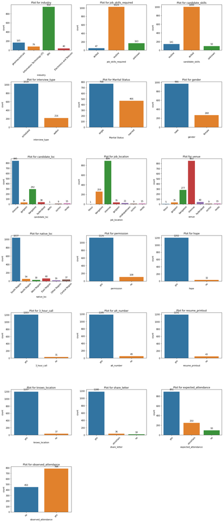

```python
import matplotlib.pyplot as plt
import seaborn as sns
import warnings

# Suppress all warnings
warnings.filterwarnings("ignore")

# Increase the size of the figure
plt.figure(figsize=(15, 15))

# Specify the columns you want to create count plots for
selected_columns = ['industry','job_skills_required',
                'candidate_skills', 'interview_type', 'Marital Status','gender', 'candidate_loc',
                'job_location', 'venue', 'native_loc', 'permission', 'hope',
                '3_hour_call', 'alt_number', 'resume_printout', 'knows_location',
                'share_letter', 'expected_attendance', 'observed_attendance',
                ]
num_cols = 3
num_rows = len(selected_columns) // num_cols + (len(selected_columns) % num_cols > 0)

# Create subplots
fig, axes = plt.subplots(num_rows, num_cols, figsize=(15, 5 * num_rows), constrained_layout=True)

# Flatten the axes for easy iteration
axes = axes.flatten()

# Create count plots for each selected column
for ax, col in zip(axes, selected_columns):
    sns.countplot(x=df[col], ax=ax)
    ax.set_title(f'Plot for {col}')
    ax.tick_params(axis='x', rotation=45)

    # Annotate each bar with its count
    for p in ax.patches:
        ax.annotate(f'{p.get_height()}', (p.get_x() + p.get_width() / 2., p.get_height()),
                    ha='center', va='center', xytext=(0, 10), textcoords='offset points')

# Remove any empty subplots
for idx in range(len(selected_columns), num_rows * num_cols):
    fig.delaxes(axes[idx])

# Adjust layout
plt.tight_layout()

# Show the plot
plt.show()
```

The term "**routine**" is generally associated with tasks or activities that are repetitive, regular, and commonly performed as part of regular procedures. In the context of job skills, labeling a skill as "routine" might imply that it involves standard, well-established procedures that are consistently applied. These skills are often fundamental and may not require specialized or advanced training.

In contrast, "**skilled**" typically refers to tasks or activities that require specific expertise, training, or a higher level of proficiency. Skilled tasks may involve a deeper understanding of the subject matter, specialized knowledge, or the ability to perform complex operations.

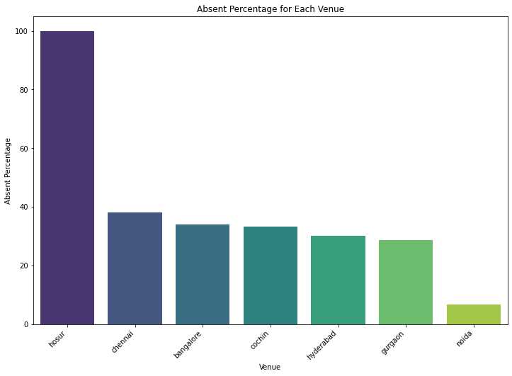

```python
import pandas as pd
import matplotlib.pyplot as plt
import seaborn as sns

# Assuming 'Venue' and 'Observed Attendance' are column names
venue_absent_counts = df.groupby(['venue', 'observed_attendance']).size().unstack().fillna(0)

# Calculate percentage of absent candidates for each venue
venue_absent_counts['Absent Percentage'] = (venue_absent_counts['no'] / (venue_absent_counts['yes'] + venue_absent_counts['no'])) * 100

# Sort venues by absent percentage in descending order
venue_absent_counts = venue_absent_counts.sort_values(by='Absent Percentage', ascending=False)

# Visualize the results
plt.figure(figsize=(12, 8))
sns.barplot(x=venue_absent_counts.index, y=venue_absent_counts['Absent Percentage'], palette='viridis')
plt.title('Absent Percentage for Each Venue')
plt.xlabel('Venue')
plt.ylabel('Absent Percentage')
plt.xticks(rotation=45, ha='right')
plt.show()
```

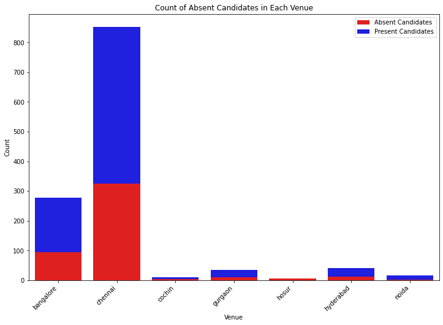

```python
import pandas as pd
import matplotlib.pyplot as plt
import seaborn as sns

# Assuming 'venue' and 'observed_attendance' are column names
venue_absent_counts = df.groupby(['venue', 'observed_attendance']).size().unstack().fillna(0)

# Calculate total candidates for each venue
venue_absent_counts['Total Candidates'] = venue_absent_counts['yes'] + venue_absent_counts['no']

# Visualize the counts
plt.figure(figsize=(12, 8))
sns.barplot(x=venue_absent_counts.index, y=venue_absent_counts['no'], color='red', label='Absent Candidates')
sns.barplot(x=venue_absent_counts.index, y=venue_absent_counts['yes'], color='blue', label='Present Candidates', bottom=venue_absent_counts['no'])
plt.title('Count of Absent Candidates in Each Venue')
plt.xlabel('Venue')
plt.ylabel('Count')
plt.legend()
plt.xticks(rotation=45, ha='right')
plt.show()
```

## Convert date into weekdays

```python
from datetime import datetime

#function to check if a character is between a-z or 1-9
def is_myalnum(char):
    return (ord(char.lower()) in range(ord('a'), ord('z')+1)
            or char.isdigit())

#extracts the day, month and year from the data
def parse_string(date_str):

    date = [] #contain [day, month, year]
    val = ""

    counter = 0
    str_len = len(date_str)

    while (len(date) < 3):
        char = date_str[counter]
        #print(counter, str_len, char, is_myalnum(char))

        if is_myalnum(char):
            val += char

        elif not is_myalnum(char) and not val == "":
            date.append(val)
            val = ""

        if counter == (str_len - 1) and not val == "":
            date.append(val)
            val = ""

        counter += 1
    return date

#converts the date into a weekday
def convert_date(data):

    [day, month, year]= parse_string(data)

    year = int(year)
    day = int(day)
    if month.isdigit():
        date = datetime(year, int(month), day)

    else:
        month = int(datetime.strptime(month, "%b").strftime("%m"))
        date = datetime(year, month, day)

    return date.strftime('%A')

df.weekday = df.weekday.apply(convert_date)
```

```python
df['client'] = df['client'].str.strip().str.replace('[^a-zA-Z0-9\s]', '')
```

```python
print(df.columns)
for col in df.columns:
    print("Unique ",col,"\n",df[col].unique())
```

```
Index(['weekday', 'client', 'industry', 'job_skills_required',
       'candidate_skills', 'interview_type', 'gender', 'candidate_loc',
       'job_location', 'venue', 'native_loc', 'permission', 'hope',
       '3_hour_call', 'alt_number', 'resume_printout', 'knows_location',
       'share_letter', 'expected_attendance', 'observed_attendance',
       'Marital Status'],
      dtype='object')
Unique  weekday
 ['Friday' 'Tuesday' 'Monday' 'Thursday' 'Wednesday' 'Sunday' 'Saturday']
Unique  client
 ['hospira' 'aon hewitt' 'ust' 'standard chartered bank' 'anz' 'pfizer'
 'aon hewitt gurgaon' 'astrazeneca' 'flextronics' 'prodapt' 'williams lea'
 'barclays' 'hewitt' 'woori bank' 'company x']
Unique  industry
 ['pharmaceuticals' 'Information Technology (IT)' 'bfsi'
 'Electronics and Telecom']
Unique  job_skills_required
 ['skilled' 'routine' 'unknown']
Unique  candidate_skills
 ['routine' 'skilled' 'unknown']
Unique  interview_type
 ['scheduled' 'walkin']
Unique  gender
 ['male' 'female']
Unique  candidate_loc
 ['chennai' 'gurgaon' 'bangalore' 'hyderabad' 'delhi' 'cochin' 'noida']
Unique  job_location
 ['hosur' 'bangalore' 'chennai' 'gurgaon' 'visakapatinam' 'cochin' 'noida']
Unique  venue
 ['hosur' 'gurgaon' 'bangalore' 'chennai' 'hyderabad' 'cochin' 'noida']
Unique  native_loc
 ['South Region' 'North Region' 'West Region' 'East Region' 'Other Region'
 'Central Region']
Unique  permission
 ['yes' 'no']
Unique  hope
 ['yes' 'no']
Unique  3_hour_call
 ['yes' 'no']
Unique  alt_number
 ['yes' 'no']
Unique  resume_printout
 ['yes' 'no']
Unique  knows_location
 ['yes' 'no']
Unique  share_letter
 ['yes' 'uncertain' 'no']
Unique  expected_attendance
 ['yes' 'uncertain' 'no']
Unique  observed_attendance
 ['no' 'yes']
Unique  Marital Status
 ['single' 'married']
```

## Label Encoding the Target Variable and Features

```python
from sklearn.preprocessing import LabelEncoder
encoder = LabelEncoder()
encoder.fit(df['observed_attendance'])
df.observed_attendance = encoder.fit_transform(df['observed_attendance'])
for col in df.drop(['observed_attendance'],axis=1).columns :
    encoder.fit(df[col])
    df[col] = encoder.transform(df[col])
df.head()
```

|  | weekday | client | industry | job_skills_required | candidate_skills | interview_type | gender | candidate_loc | job_location | venue | ... | permission | hope | 3_hour_call | alt_number | resume_printout | knows_location | share_letter | expected_attendance | observed_attendance | Marital Status |
| --- | --- | --- | --- | --- | --- | --- | --- | --- | --- | --- | --- | --- | --- | --- | --- | --- | --- | --- | --- | --- | --- |
| 0 | 0 | 8 | 3 | 1 | 0 | 0 | 1 | 1 | 4 | 4 | ... | 1 | 1 | 1 | 1 | 1 | 1 | 2 | 2 | 0 | 1 |
| 1 | 0 | 8 | 3 | 1 | 0 | 0 | 1 | 1 | 0 | 4 | ... | 1 | 1 | 1 | 1 | 1 | 1 | 2 | 2 | 0 | 1 |
| 2 | 0 | 8 | 3 | 1 | 0 | 0 | 1 | 1 | 1 | 4 | ... | 1 | 0 | 1 | 1 | 1 | 1 | 2 | 1 | 0 | 1 |
| 3 | 0 | 8 | 3 | 1 | 0 | 0 | 1 | 1 | 1 | 4 | ... | 1 | 1 | 0 | 1 | 0 | 1 | 2 | 1 | 0 | 1 |
| 4 | 0 | 8 | 3 | 1 | 0 | 0 | 1 | 1 | 0 | 4 | ... | 1 | 1 | 1 | 0 | 1 | 1 | 2 | 1 | 0 | 0 |

5 rows × 21 columns

## Correlation Matrix

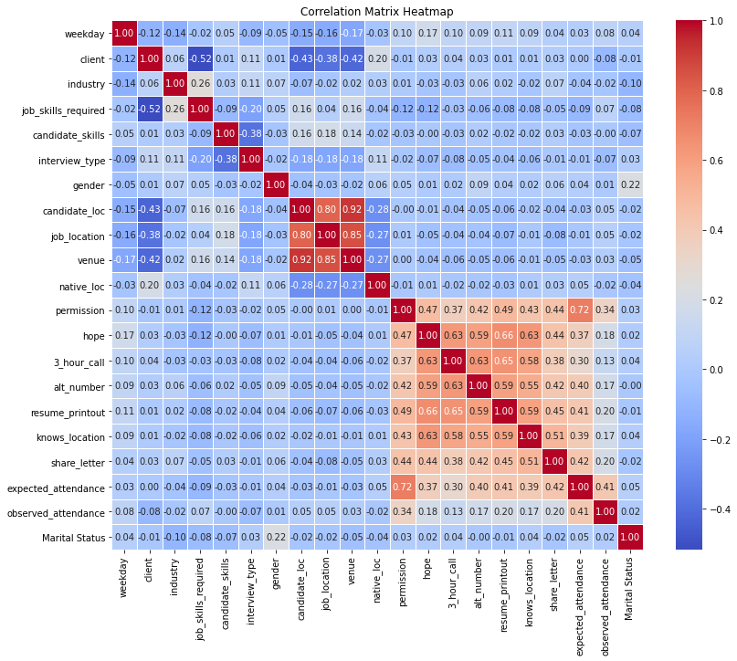

```python
# Set up the matplotlib figure
plt.figure(figsize=(12, 10))
correlation_matrix = df.corr()

# Create a heatmap using Seaborn
sns.heatmap(correlation_matrix, annot=True, cmap="coolwarm", fmt=".2f", linewidths=0.5)

# Adjust layout to prevent cutoff of labels
plt.tight_layout()

# Save the plot
plt.title("Correlation Matrix Heatmap")
plt.savefig("correlation_matrix_heatmap.jpg")

# Show the plot
plt.show()
```

```python
y = df['observed_attendance']
df.drop('observed_attendance', axis=1, inplace=True)
```

```python
from sklearn.feature_selection import RFE
from sklearn import linear_model
regr=linear_model.LinearRegression()
rfe=RFE(regr, 3)
fit=rfe.fit(df,y)
print("coeficient ie. scores is  ",fit.ranking_)
print ("Features sorted by their rank:")
print (sorted(zip(map(lambda X: round(X, 4), fit.ranking_), df.columns)))
```

```
coeficient ie. scores is   [13 18 10  3 15  5 12 11  7  8 17  1  1  2 16  4  6  9  1 14]
Features sorted by their rank:
[(1, 'expected_attendance'), (1, 'hope'), (1, 'permission'), (2, '3_hour_call'), (3, 'job_skills_required'), (4, 'resume_printout'), (5, 'interview_type'), (6, 'knows_location'), (7, 'job_location'), (8, 'venue'), (9, 'share_letter'), (10, 'industry'), (11, 'candidate_loc'), (12, 'gender'), (13, 'we…
```

```python
# Feature selection result
feature_ranking = fit.ranking_

# Get indices of top 15 features
top_15_indices = np.argsort(feature_ranking)[:15]
# Define the columns for independent variables based on top 15 features
```

```python
independent_columns = df.columns[top_15_indices]
# Create a new DataFrame with independent variables
df1 = df[independent_columns]
# Check column names in df1
print(df1.columns)

# Drop the dependent variable from the independent variable DataFrame
df1.drop('expected_attendance', axis=1, inplace=True)
```

```
Index(['expected_attendance', 'permission', 'hope', '3_hour_call',
       'job_skills_required', 'resume_printout', 'interview_type',
       'knows_location', 'job_location', 'venue', 'share_letter', 'industry',
       'candidate_loc', 'gender', 'weekday'],
      dtype='object')
```

## Choose and Train Models

```python
from sklearn.model_selection import train_test_split
X_train, X_test, y_train, y_test = train_test_split(df1, y, train_size=0.8, random_state=123)
```

## DECISION TREE

```
Decision Tree Classifier Accuracy: 0.6842105263157895
Precision: 0.6756756756756757
Recall: 0.9615384615384616
```

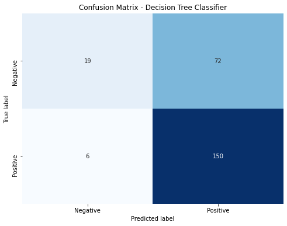

```python
from sklearn.tree import DecisionTreeClassifier
from sklearn.metrics import accuracy_score, precision_score, recall_score, confusion_matrix
import matplotlib.pyplot as plt
import seaborn as sns

# Create the Decision Tree Classifier
dt_model = DecisionTreeClassifier(max_depth=5, random_state=123)

# Fit the model to the training data
dt_model.fit(X_train, y_train)

# Make predictions on the test data
dt_predictions = dt_model.predict(X_test)

# Evaluate performance
# Calculate accuracy
dt_accuracy = accuracy_score(y_test, dt_predictions)
print("Decision Tree Classifier Accuracy:", dt_accuracy)

# Calculate precision
dt_precision = precision_score(y_test, dt_predictions)
print("Precision:", dt_precision)

# Calculate recall
dt_recall = recall_score(y_test, dt_predictions)
print("Recall:", dt_recall)

# Generate and display a confusion matrix
plt.figure(figsize=(8, 6))
sns.heatmap(confusion_matrix(y_test, dt_predictions), annot=True, fmt='d', cmap='Blues', cbar=False,
            xticklabels=['Negative', 'Positive'], yticklabels=['Negative', 'Positive'])
plt.title('Confusion Matrix - Decision Tree Classifier')
plt.xlabel('Predicted label')
plt.ylabel('True label')
plt.show()
```

## SVM

```
SVM Accuracy: 0.7004048582995951
SVM Precision: 0.6814159292035398
SVM Recall: 0.9871794871794872
```

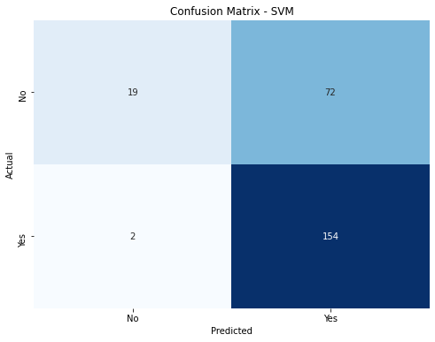

```python
from sklearn.svm import SVC
from sklearn.metrics import accuracy_score, confusion_matrix
import seaborn as sns
import matplotlib.pyplot as plt
from sklearn.model_selection import train_test_split

# Assuming X_train, X_test, y_train, y_test are already defined

# Create an SVM classifier
svm_model = SVC(kernel='linear', random_state=500)

# Fit the model on the training data
svm_model.fit(X_train, y_train)

# Predictions on the test set
svm_predictions = svm_model.predict(X_test)

# Evaluate performance
svm_accuracy = accuracy_score(y_test, svm_predictions)

# Display accuracy score
print("SVM Accuracy:", svm_accuracy)
# Calculate precision for SVM
svm_precision = precision_score(y_test, svm_predictions)
print("SVM Precision:", svm_precision)

# Calculate recall for SVM
svm_recall = recall_score(y_test, svm_predictions)
print("SVM Recall:", svm_recall)


# Confusion Matrix for SVM
plt.figure(figsize=(8, 6))
sns.heatmap(confusion_matrix(y_test, svm_predictions), annot=True, fmt='d', cmap='Blues', cbar=False,
            xticklabels=['No', 'Yes'], yticklabels=['No', 'Yes'])
plt.title('Confusion Matrix - SVM')
plt.xlabel('Predicted')
plt.ylabel('Actual')
plt.show()
```